# Reinforcement Learning Pricing

### Below we try to simulate a Deep Q Neural Net Reinforcement model to come up with a price that delivers optimal return

```python
import tensorflow as tf
from keras import Sequential
from keras.layers import Activation, Dense
from keras.optimizers import Adam
import numpy as np
import math
import random
from collections import deque
!pip install gym
```

```
You are using pip version 10.0.1, however version 19.1.1 is available.
```

```python
import matplotlib.pyplot as plt
import plotly
import plotly.plotly as py
import plotly.graph_objs as go
from plotly.offline import download_plotlyjs, init_notebook_mode, plot, iplot

init_notebook_mode(connected = True)
```

# MODEL

```python
class DQNN:

    def __init__(self,state_size,action_size):
        self.state_size = state_size
        self.action_size = action_size
        self.model = self._build()
        self.memory = deque(maxlen=1000)
        self.gamma = 0.95
        self.epsilon = 0.5
        self.epsilon_min = 0.2
        self.epsilon_decay = 0.995

    def _build(self):
        model = Sequential()
        model.add(Dense(24, input_dim=self.state_size, activation='relu'))
        model.add(Dense(24, activation='relu'))
        model.add(Dense(self.action_size, activation='linear'))
        model.compile(loss='mse',
                      optimizer=Adam(lr=0.01))
        return model

    def act(self,state):
        if np.random.rand()<self.epsilon:
            return np.random.randint(0,2)
        action = self.model.predict(state)
        action = np.argmax(action[0])
        return action

    def remember(self, state, action, reward, next_state, done):
        self.memory.append((state, action, reward, next_state, done))

    def revise(self,minibatchsize):
        minibatch = random.sample(self.memory, minibatchsize)

        for state, action, reward, next_state,done in minibatch:
            target_f = self.model.predict(np.array([(next_state)]))
            # if done, make our target reward
            target = reward
            if not done:
                # predict the future discounted reward
                #bellman Equation
                target = reward + self.gamma * \
                       np.amax(self.model.predict(np.array([next_state]))[0])
            #make the agent to approximately map
            #the current state to future discounted reward
            #We'll call that target_f
            target_f = self.model.predict(np.array([state]))
            target_f[0][action] = target
            #Train the Neural Net with the state and target_f
            self.model.fit(np.array([state]), target_f, epochs=1, verbose=0)

            #reduce the randomness of the model gradually
            if(self.epsilon>self.epsilon_min):
                self.epsilon*=self.epsilon_decay
```

# ENVIRONMENT

```python
import gym
from gym import error, spaces, utils
from gym.utils import seeding

class ArrivalSim(gym.Env):
    metadata = {'render.modes': ['human']}

    def __init__(self, price):
        self.price = price
        self.action_space = [0,1]  #increase or decrease

#         super(CustomEnv, self).__init__()
#         # Define action and observation space
#         # They must be gym.spaces objects
#         # Example when using discrete actions:
#         self.action_space = spaces.Discrete(N_DISCRETE_ACTIONS)
#         # Example for using image as input:
#         self.observation_space = spaces.Box(low=0, high=255,
#                                             shape=(HEIGHT, WIDTH, N_CHANNELS), dtype=np.uint8)

    def _state(self):
        return self.price


    def _step(self,action):
        state = self.price
        self._take_action(action)
        next_state = self.price
        reward = self._get_reward()
        done = False
        if(self.price<0):
            done=True
        elif(self._get_reward()==0):
            done = True
        return state, action, reward, next_state, done


    def _reset(self):
        self.price = np.random.rand()


    def _take_action(self, action):
        if(action == 1):
            self.price+= 0.25
        elif(action==0):
            self.price-=0.25


    def sigmoid(self,x,maxcust,gamma):
        return (maxcust/(1+math.exp(gamma*max(0,x))))

    def _get_reward(self):
        return max(np.random.poisson(self.sigmoid(self.price,50,0.5))*self.price,0)
```

where $\lambda$ is the rate of arrival of people and $\gamma$ is the "elasticity"

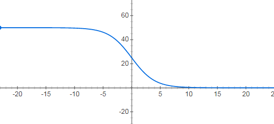

this decreases the rate of arrival of people $\lambda$ through the poisson distribution with increase in price and vice versa. The reward is given by the money generated through sales at each timestep to train the model.

```python
env = ArrivalSim(0.4)
```

```python
agent = DQNN(1,2)
```

# TRAIN

```python
plotdata = []
for step in range(0,750):
    agent.memory = []
    env._reset()
    state = env._state()
    total_profit = 0
    for time_t in range(500):


        # turn this on if you want to render
        # env.render()
        # Decide action
        action = agent.act(np.array([state]))
        # Advance the simulation to the next frame based on the action.
        # Reward is 1 for every frame the pole survived
        state, action, reward, next_state,done = env._step(action)
        #next_state = np.reshape(next_state, [1, 4])
        # Remember the previous state, action, reward, and done
        agent.remember(state, action, reward, next_state,done)
        # make next_state the new current state for the next frame.

        state = next_state
        total_profit += env._get_reward()
    print("Final Price (End Of Episode {}): {}".format(step,env.price))
    print("Total Profit: {}".format(total_profit))
    plotdata.append([step,total_profit])
    agent.revise(32)
```

```
Final Price (End Of Episode 0): 56.604785237618145
Total Profit: 1671.227585442346
Final Price (End Of Episode 1): -67.43332701945232
Total Profit: 16.00056824929089
Final Price (End Of Episode 2): 1.1241151874343691
Total Profit: 7343.765613208572
Final Price (End Of Episode 3): 88.11090392819665
.
.
.
.
.

Total Profit: 14021.346782063994
Final Price (End Of Episode 737): 1.9247076881267873
Total Profit: 13216.955972552349
Final Price (End Of Episode 738): 2.219098495386395
Total Profit: 13319.643007974657
Final Price (End Of Episode 739): 2.667179907696631
Total Profit: 14105.557240147416
Final Price (End Of Episode 740): 2.9981336913086625
Total Profit: 13999.317419780069
Final Price (End Of Episode 741): 3.167980043028183
Total Profit: 13948.771962748791
Final Price (End Of Episode 742): 1.8567932411054322
Total Profit: 13427.0288069477
Final Price (End Of Episode 743): 1.7805824575193476
Total Profit: 13084.352444753082
Final Price (End Of Episode 744): 2.370531911747683
Total Profit: 13514.695619161175
Final Price (End Of Episode 745): 2.4808594319719894
Total Profit: 13959.776125702652
Final Price (End Of Episode 746): 2.2815333976724474
Total Profit: 13828.423179858168
Final Price (End Of Episode 747): 2.548564540582892
Total Profit: 13740.773141000924
Final Price (End Of Episode 748): 2.3275277579793787
Total Profit: 13906.890951455602
Final Price (End Of Episode 749): 2.530910501146002
Total Profit: 13684.368206168581
```

### So what is the model doing?

The model has between two choices to make (increase the price by 0.25 or decrease the price by 0.25) or 1/0

It does this by spitting out an array of two values of which the larger one is chosen to be the action. eg [50,1] so the action is 0

The model makes a choice to which the environment calculates and returns a reward. The reward is given by:

reward = Po($ \lambda $)x price = Po(sigmoid(-$ \gamma $x price) x price

If the reward is high then the chosen action gets reinforced by adding the reward to the respective part in the array.

eg reward is 5 then the array will be [~55,1] - approximate as it also adds a discounted future prediction of the same action.

over time the correct actions get reinforced.

```python
trace = go.Scatter(
    x =[x[0] for x in plotdata],
    y = [x[1] for x in plotdata]
)
data = [trace]
layout = go.Layout(
    xaxis=dict(
        title = 'EPISODE',
        autorange=True,
        showgrid=False,
        zeroline=False,
        showline=False,
        ticks='',
        showticklabels=False
    ),
    yaxis=dict(
        title = 'TOTAL PROFIT PER EPISODE',
        autorange=True,
        showgrid=False,
        zeroline=False,
        showline=False

    )
)

fig = go.Figure(data=data, layout=layout)
iplot(fig, filename='axes-booleans')
```

[interactive chart not shown]

We can see above that the total profit gradually increases with more and more iterations.